# The Ford GoBike System Data

## by John Magdy

## Investigation Overview

> Visualizing finding from the collected data, finding patterns, information about certian people in the data and how we can understand these findings.

## Dataset Overview

> The Ford GoBike Dataset being used is the 2018 data seperated for each month of the year it inclued information about individual rides made in a bike-sharing system covering the greater San Francisco Bay area. by grouping each dataset to get the entirety of 2018 data and do the required exploratory and explanatory analysis on it.

## (Visualization 1)

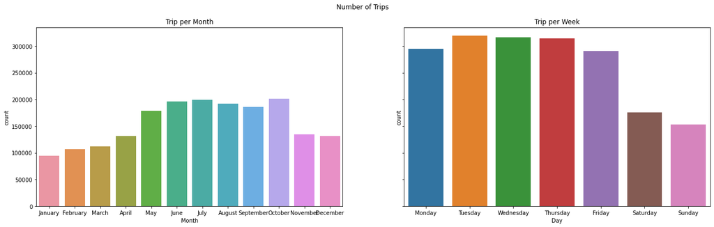

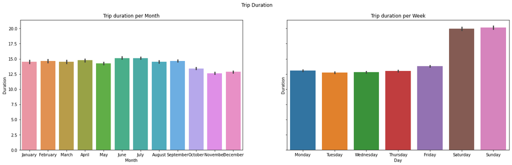

## (Visualization 2)

> In this visualization its apparent that females tend to ride their bikes longer than males in each day of the week and in general overall. during weekends in particular.

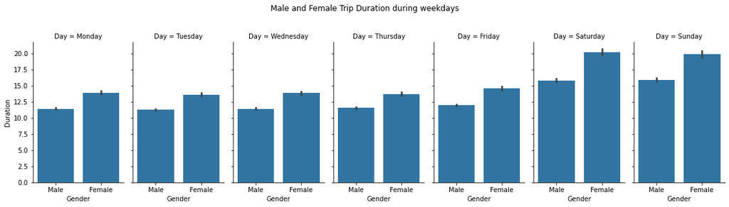

## (Visualization 3)

> For the customer vs subscriber activity per hour in each day of the week there is quite a noticable difference in both user types patterns. most noticable in the days is that subscribers are way less active during weekends while customers are most active in the weekends.the active hours during the normal days are usually in the early morning or between 4 pm to 7 pm while in weekends its during the mid day

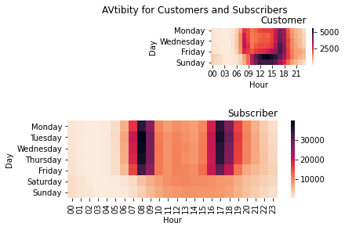

[output not shown]